# Data Related jobs

Khuong Le & Shiyong Liu

July 23, 2018

Introduction: In this project, we performed data analysis using R language on job demand across data related field to help people better understand the basic requirement and information on data - related jobs in California State.

First of all, we used excel to create the data set that will later be imported in r markdown file for the analysis.Then, we targetted job demanding social networking sites such as glassdoor, Indeed and Linkedin to help creating the variables for our data set.

During the analysis, the graphs are created for visualization and functions are created for searching. The github is used to help creating a collaborative repository to store the work files that are created in R markdown.

Load different packages that will use in this model:

```r
pkg_list = c("ggplot2", "plyr", "stringr", "VennDiagram")
mia_pkgs = pkg_list[!(pkg_list %in% installed.packages()[,"Package"])]
if(length(mia_pkgs) > 0) install.packages(mia_pkgs)
loaded_pkgs = lapply(pkg_list, require, character.only=TRUE)
```

Set up the data:

```r
jdata = read.csv("datarelatedjobs.csv")
jdata$X = NULL
names(jdata)
```

```
##  [1] "City"               "Company"            "Region"
##  [4] "Position"           "Employment_type"    "Industry"
##  [7] "Standing"           "Preferred_mj1"      "Preferred_mj2"
## [10] "Preferred_lang1"    "Preferred_lang2"    "Min_exp"
## [13] "Est_min_avg_salary"
```

```r
summary(jdata)
```

```
##             City                 Company         Region
##  San Francisco:153   Amazon          :  5   North CA:355
##  Los Angeles  : 61   Apple           :  5   South CA:194
##  San Jose     : 36   East West Bank  :  5
##  Mountain View: 29   Google          :  5
##  San Diego    : 28   Qventus         :  4
##  San Mateo    : 20   Riviera Partners:  4
##  (Other)      :222   (Other)         :521
##                       Position     Employment_type
##  Data Scientist           :159   Contract  : 14
##  Data Analyst             : 70   Full time :487
##  Data Engineer            : 49   Internship: 45
##  Senior Data Scientist    : 11   Part time :  2
##  Senior Data Engineer     : 10   Temporary :  1
##  Machine Learning Engineer:  6
##  (Other)                  :244
##                                 Industry         Standing
##  Information Technology             :153   All levels: 90
##  Information Technology and Services: 50   MS/PH.D   : 79
##  Business Services                  : 49   BS        : 75
##  Finance                            : 34   BA/BS     : 53
##  Computer Software                  : 31   BS/BA     : 47
##  Media                              : 28   (Other)   : 98
##  (Other)                            :204   NA's      :107
##                  Preferred_mj1                 Preferred_mj2
##  Computer Science       :249   Statistics             : 97
##  Statistics             : 73   Related Technical Field: 60
##  Related Technical Field: 41   Engineering            : 47
##  Machine Learning       : 23   Math                   : 35
##  Math                   : 20   Computer Science       : 31
##  Data Engineering       : 16   (Other)                :201
##  (Other)                :127   NA's                   : 78
##  Preferred_lang1                     Preferred_lang2    Min_exp
##  SQL    :228     Python                      :129    Min.   : 0.000
##  Python :114     R                           : 88    1st Qu.: 1.000
##  R      : 50     SQL                         : 53    Median : 2.000
##  Java   : 26     Java                        : 27    Mean   : 2.577
##  C/C++  : 18     Related Programming Language: 26    3rd Qu.: 3.000
##  (Other):112     (Other)                     :225    Max.   :10.000
##  NA's   :  1     NA's                        :  1
##  Est_min_avg_salary
##  Min.   : 34000
##  1st Qu.: 74000
##  Median :103000
##  Mean   :100319
##  3rd Qu.:123000
##  Max.   :195394
##  NA's   :179
```

```r
str(jdata)
```

```
## 'data.frame':    549 obs. of  13 variables:
##  $ City              : Factor w/ 81 levels "Alameda","Alhambra",..: 63 64 74 39 44 38 71 38 17 17 ...
##  $ Company           : Factor w/ 446 levels "21st Century Fox",..: 433 157 45 45 45 166 94 117 43 43 ...
##  $ Region            : Factor w/ 2 levels "North CA","South CA": 1 1 2 2 2 2 1 2 1 1 ...
##  $ Position          : Factor w/ 219 levels "A9 Fall 2018 Applied Scientist Intern",..: 27 9 122 186 186 27 206 80 55 80 ...
##  $ Employment_type   : Factor w/ 5 levels "Contract","Full time",..: 2 2 2 2 2 3 2 3 2 2 ...
##  $ Industry          : Factor w/ 80 levels "Accounting & Legal",..: 21 21 21 31 21 12 51 55 24 24 ...
##  $ Standing          : Factor w/ 16 levels "All levels","BA",..: 3 12 16 1 10 6 12 6 6 12 ...
##  $ Preferred_mj1     : Factor w/ 62 levels "Accounting","Analytic Discipline",..: 18 18 16 16 18 18 56 18 18 31 ...
##  $ Preferred_mj2     : Factor w/ 59 levels "Accounting","Administrative/Management analysis field",..: 37 56 37 15 14 4 25 5 25 25 ...
##  $ Preferred_lang1   : Factor w/ 76 levels "3D Modeling Tools ( Illustrator, SketchUp, or Poly)",..: 69 57 57 13 34 69 69 57 31 69 ...
##  $ Preferred_lang2   : Factor w/ 91 levels "Access","Adobe",..: 60 34 12 69 33 69 69 75 81 69 ...
##  $ Min_exp           : int  4 1 2 2 3 1 5 1 1 1 ...
##  $ Est_min_avg_salary: int  67000 107869 NA 87000 87000 NA 146464 137548 127276 141188 ...
```

Transform the data.

```r
jdata$Preferred_mj1 = as.character(jdata$Preferred_mj1)
jdata$Preferred_mj2 = as.character(jdata$Preferred_mj2)

for(i in 1:length(jdata$Standing)){
  if(is.na(jdata$Standing[i])){
    jdata$Standing[i] = "All levels"
  }
}
for(i in 1:length(jdata$Preferred_mj1)){
  if(is.na(jdata$Preferred_mj1[i])){
    jdata$Preferred_mj1[i] = "Data_related"
  }
  if(is.na(jdata$Preferred_mj2[i])){
      jdata$Preferred_mj2[i] = "Data_related"
  }
}
count(jdata$Preferred_mj2)[order(count(jdata$Preferred_mj2)$freq, decreasing = T),]
```

```
##                                           x freq
## 57                               Statistics   97
## 23                             Data_related   78
## 52                  Related Technical Field   60
## 26                              Engineering   47
## 38                                     Math   35
## 15                         Computer Science   31
## 17                         Data Engineering   27
## 35                         Machine Learning   15
## 48                            Related field   14
## 14                     Computer Engineering   13
## 46                      Quantitative fields   13
## 20                       Data Related field   12
## 24                                Economics   10
## 4                       Applied Mathematics    8
```

[output cut: 46 more lines]

```r
head(jdata,10)
```

```
##             City            Company   Region
## 1  San Francisco               Wish North CA
## 2       San Jose               FICO North CA
## 3   Santa Monica              Aptiv South CA
## 4         Malibu              Aptiv South CA
## 5         Monica              Aptiv South CA
## 6    Los Angeles Fox Networks Group South CA
## 7    Santa Clara              Chegg North CA
## 8    Los Angeles       Cyber Coders South CA
## 9      Cupertino              Apple North CA
## 10     Cupertino              Apple North CA
##                              Position Employment_type
## 1                        Data Analyst       Full time
## 2    Artificial intelligence Engineer       Full time
## 3  Machine Learning Computer Engineer       Full time
```

[output cut: 40 more lines]

1. Comparing between companies in the North and the South of California (using side-by-side histogram):
- Number of Cities.
- Number of companies in North vs South
- Average minimum experience.
- Average salary in North vs South

Set up number of cities.

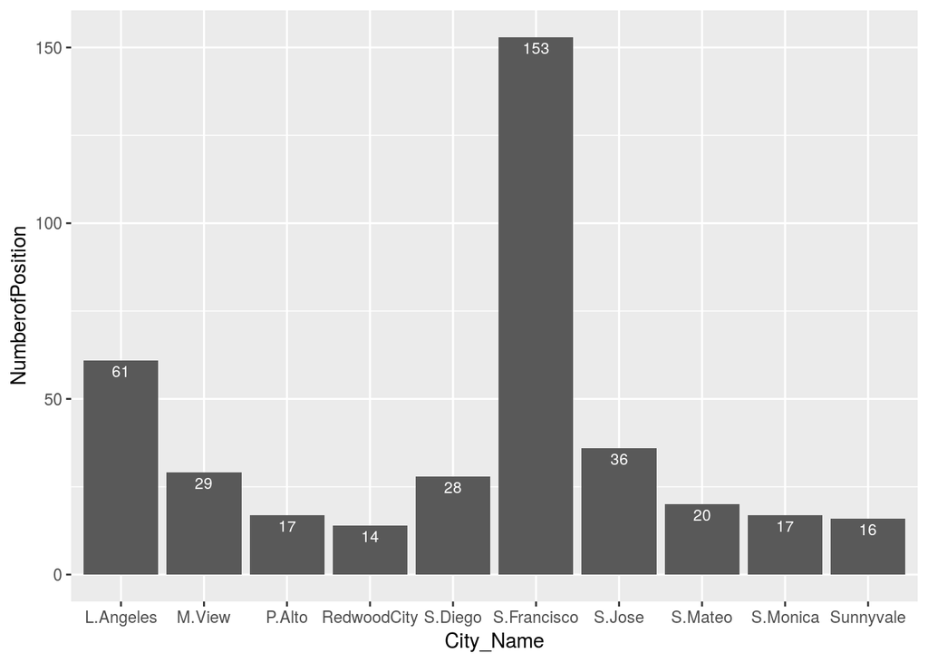

```r
ct_City = count(jdata$City)
topCity = ct_City[order(ct_City$freq, decreasing = T),]

tCitydf = data.frame(City_Name =  c("S.Francisco" , "L.Angeles" , "S.Jose" , "M.View" , "S.Diego", "S.Mateo" , "P.Alto", "S.Monica", "Sunnyvale" , "RedwoodCity"),
                     NumberofPosition = c(topCity$freq[1:10]))

city_plotg = ggplot(data = tCitydf, aes(x = City_Name, y = NumberofPosition)) +
    geom_bar(stat = "identity", position=position_dodge()) +
    geom_text(aes(label = NumberofPosition), position = position_dodge(0.95), vjust= 1.5, color = "white", size = 3)
#jpeg('city_plotg.jpg')
#plot(city_plotg)
city_plotg
```

Set up 2 subsets for North and South:

```r
North_sub = jdata[which(jdata$Region == "North CA"),]
head(North_sub,5)
```

```
##             City Company   Region                         Position
## 1  San Francisco    Wish North CA                     Data Analyst
## 2       San Jose    FICO North CA Artificial intelligence Engineer
## 7    Santa Clara   Chegg North CA             Staff Data Scientist
## 9      Cupertino   Apple North CA                    Data Engineer
## 10     Cupertino   Apple North CA                   Data Scientist
##    Employment_type                        Industry Standing
## 1        Full time               Computer Software    BA/BS
## 2        Full time               Computer Software       MS
## 7        Full time Information Technology&Services       MS
## 9        Full time             Consumer Electronic       BS
## 10       Full time             Consumer Electronic       MS
##                          Preferred_mj1 Preferred_mj2 Preferred_lang1
## 1                     Computer Science          Math             SQL
## 2                     Computer Science    Statistics          Python
## 7                             Sciences   Engineering             SQL
## 9                     Computer Science   Engineering            Java
## 10 Economics or Quantitative Marketing   Engineering             SQL
##    Preferred_lang2 Min_exp Est_min_avg_salary
## 1              PHP       4              67000
## 2             Java       1             107869
## 7                R       5             146464
## 9              SQL       1             127276
## 10               R       1             141188
```

```r
South_sub = jdata[which(jdata$Region == "South CA"),]
head(South_sub,5)
```

```
##           City            Company   Region
## 3 Santa Monica              Aptiv South CA
## 4       Malibu              Aptiv South CA
## 5       Monica              Aptiv South CA
## 6  Los Angeles Fox Networks Group South CA
## 8  Los Angeles       Cyber Coders South CA
##                             Position Employment_type
## 3 Machine Learning Computer Engineer       Full time
## 4                  Software Engineer       Full time
## 5                  Software Engineer       Full time
## 6                       Data Analyst      Internship
## 8                     Data Scientist      Internship
##                  Industry   Standing        Preferred_mj1
## 3       Computer Software       PH.D Computer Engineering
## 4 Electrical Manfacturing All levels Computer Engineering
## 5       Computer Software      BS/MS     Computer Science
## 6         Broadcast Media         BS     Computer Science
## 8                Internet         BS     Computer Science
##                 Preferred_mj2 Preferred_lang1 Preferred_lang2 Min_exp
## 3                        Math          Python           C/C++       2
## 4            Computer Science           C/C++               R       2
## 5        Computer Engineering      JavaScript            HTML       3
## 6         Applied Mathematics             SQL               R       1
## 8 Applied quantitative fields          Python           Scala       1
##   Est_min_avg_salary
## 3                 NA
## 4              87000
## 5              87000
## 6                 NA
## 8             137548
```

Number of companies:

```r
n_companies_north = rep(0, length(count(North_sub$Company)$freq))
n_companies_south = rep(0, length(count(South_sub$Company)$freq))

for(i in 1:length(count(North_sub$Company)$freq)){
  if(count(North_sub$Company)$freq[i] == 1){
    n_companies_north[i] = count(North_sub$Company)$freq[i]
  } else{
    n_companies_north[i] = 1
  }
}

for(i in 1:length(count(South_sub$Company)$freq)){
  if(count(South_sub$Company)$freq[i] == 1){
    n_companies_south[i] = count(South_sub$Company)$freq[i]
  } else{
    n_companies_south[i] = 1
  }
}
sum(n_companies_north)
```

```
## [1] 292
```

```r
sum(n_companies_south)
```

```
## [1] 158
```

Average minimum experience:

```r
avg_exp_N = round(mean(North_sub$Min_exp)*12,0)
avg_exp_S = round(mean(South_sub$Min_exp)*12,0)
avg_exp_N
```

```
## [1] 31
```

```r
avg_exp_S
```

```
## [1] 31
```

Average salary:

Top 10 cities:

```r
jdata_salary = jdata[which(jdata$Est_min_avg_salary != "NA"),]
mean(jdata_salary$Est_min_avg_salary[which(jdata_salary$City == "San Francisco")])
```

```
## [1] 109568.2
```

```r
mean(jdata_salary$Est_min_avg_salary[which(jdata_salary$City == "Los Angeles")])
```

```
## [1] 92885.86
```

```r
mean(jdata_salary$Est_min_avg_salary[which(jdata_salary$City == "San Jose")])
```

```
## [1] 96097.35
```

```r
mean(jdata_salary$Est_min_avg_salary[which(jdata_salary$City == "Mountain View")])
```

```
## [1] 111298.6
```

```r
mean(jdata_salary$Est_min_avg_salary[which(jdata_salary$City == "San Diego")])
```

```
## [1] 73909.09
```

```r
mean(jdata_salary$Est_min_avg_salary[which(jdata_salary$City == "San Mateo")])
```

```
## [1] 102081.5
```

```r
mean(jdata_salary$Est_min_avg_salary[which(jdata_salary$City == "Palo Alto")])
```

```
## [1] 99512.22
```

```r
mean(jdata_salary$Est_min_avg_salary[which(jdata_salary$City == "Santa Monica")])
```

```
## [1] 97750.92
```

```r
mean(jdata_salary$Est_min_avg_salary[which(jdata_salary$City == "Sunnyvale")])
```

```
## [1] 110130.7
```

```r
mean(jdata_salary$Est_min_avg_salary[which(jdata_salary$City == "Redwood City")])
```

```
## [1] 118454.5
```

North vs South

```r
#Use NA.omit to omit to take out NA values then use mean function to find average
Omit_yr_salary_N = na.omit(North_sub$Est_min_avg_salary)
Omit_yr_salary_S = na.omit(South_sub$Est_min_avg_salary)
North_Est_min_salary = round(mean(Omit_yr_salary_N)/1000,2)
South_Est_min_salary = round(mean(Omit_yr_salary_S)/1000,2)

max(Omit_yr_salary_N)
```

```
## [1] 195394
```

```r
min(Omit_yr_salary_N)
```

```
## [1] 35000
```

```r
max(Omit_yr_salary_S)
```

```
## [1] 161000
```

```r
min(Omit_yr_salary_S)
```

```
## [1] 34000
```

```r
North_Est_min_salary
```

```
## [1] 108.38
```

```r
South_Est_min_salary
```

```
## [1] 85.26
```

Setting up the dataframe for histogram:

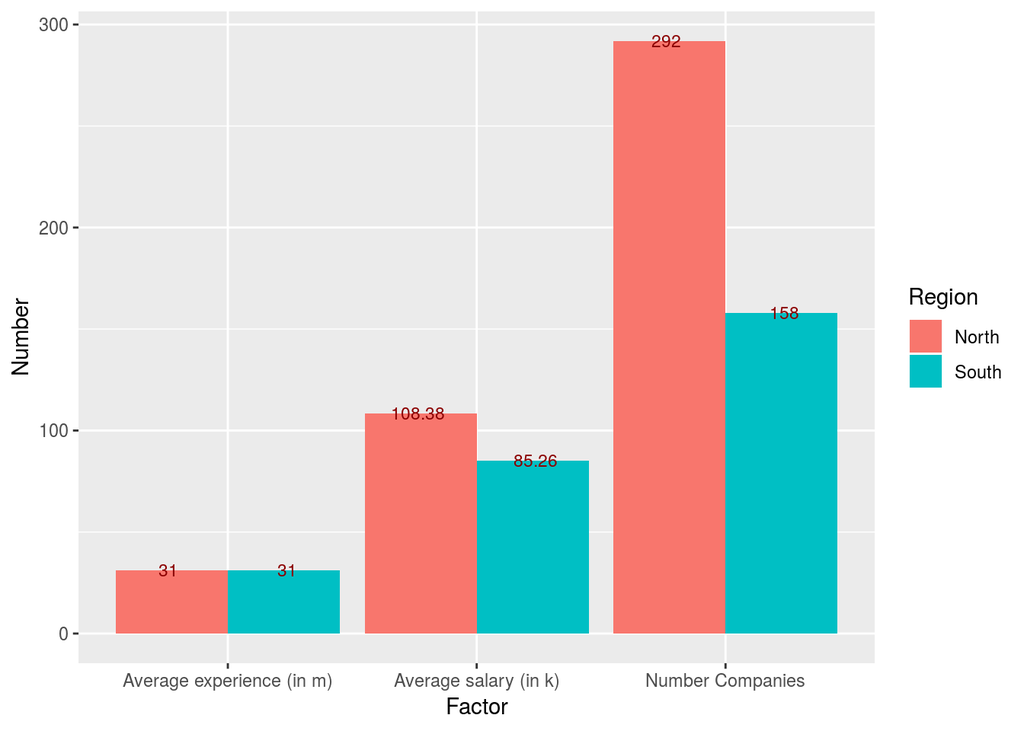

```r
firstdf = data.frame(
          Region = rep(c("North", "South"), each = 3),
          Factor = rep(c("Average experience (in m)", "Average salary (in k)","Number Companies")),
          Number = c(avg_exp_N, North_Est_min_salary, sum(n_companies_north),
                     avg_exp_S, South_Est_min_salary, sum(n_companies_south)))

plotfirst = ggplot(data = firstdf, aes(x = Factor, y = Number, fill = Region)) +
    geom_bar(stat = "identity", position=position_dodge()) +
    geom_text(aes(label = Number), position = position_dodge(0.95), vjust=0.5, color = "darkred", size = 3)

# jpeg('plotfirst.jpg')
# plot(plotfirst)
plotfirst
```

2. Comparing between companies in the North and the South of California (using side-by-side histogram):
- Number of Bachelor’s, Master’s, Ph.D that companies recruiting in North vs South. (All levels = add 1 to every value)
- Top 5 most used languages.
- Top 5 major needs.

```r
#Nearly same as counting number of companies:
#Create 3 vectors: n_bach, n_master, n_phd to store the values.
#For this one we need to use stringr.
#Ex: All levels -> n_bach = n_bach + 1, n_master = n_master + 1, n_phd = n_phd + 1
#BS/MS ->  n_bach = n_bach + 1, n_master = n_master + 1 (Use  stringr so that we can get only BS or only MS)
Standing_sub = jdata[which(jdata$Standing != "NA"),]
North_sub_st = Standing_sub[which(Standing_sub$Region == "North CA"),]
South_sub_st = Standing_sub[which(Standing_sub$Region == "South CA"),]
```

String R, numbers of standing South:

```r
n_bach_S = length(str_subset(South_sub_st$Standing, pattern = "^B")) + count(South_sub_st$Standing)$freq[which(count(South_sub_st$Standing) == "All levels")]
n_bach_S
```

```
## [1] 154
```

```r
n_master_S = length(str_subset(South_sub_st$Standing, pattern = "^MS")) + length(str_subset(South_sub_st$Standing, pattern = "MS$")) + count(South_sub_st$Standing)$freq[which(count(South_sub_st$Standing) == "All levels")] - length(str_subset(South_sub_st$Standing, pattern = "^MS$"))
n_master_S
```

```
## [1] 117
```

```r
n_PH.D_S = length(str_subset(South_sub_st$standing, pattern = "^PH.D")) + length(str_subset(South_sub_st$Standing, pattern = "PH.D$")) + count(South_sub_st$Standing)$freq[which(count(South_sub_st$Standing) == "All levels")]
n_PH.D_S
```

```
## [1] 97
```

String R, numbers of standing North:

```r
n_bach_N = length(str_subset(North_sub_st$Standing, pattern = "^B")) + count(North_sub_st$Standing)$freq[which(count(North_sub_st$Standing) == "All levels")]
n_bach_N
```

```
## [1] 267
```

```r
n_master_N = length(str_subset(North_sub_st$Standing, pattern = "^MS")) + length(str_subset(North_sub_st$Standing, pattern = "MS$")) + count(North_sub_st$Standing)$freq[which(count(North_sub_st$Standing) == "All levels")] - length(str_subset(North_sub_st$Standing, pattern = "^MS$"))
n_master_N
```

```
## [1] 235
```

```r
n_PH.D_N = length(str_subset(North_sub_st$standing, pattern = "^PH.D")) + length(str_subset(North_sub_st$Standing, pattern = "PH.D$")) + count(North_sub_st$Standing)$freq[which(count(North_sub_st$Standing) == "All levels")]
n_PH.D_N
```

```
## [1] 196
```

Create dataframe to plot out our histogram:

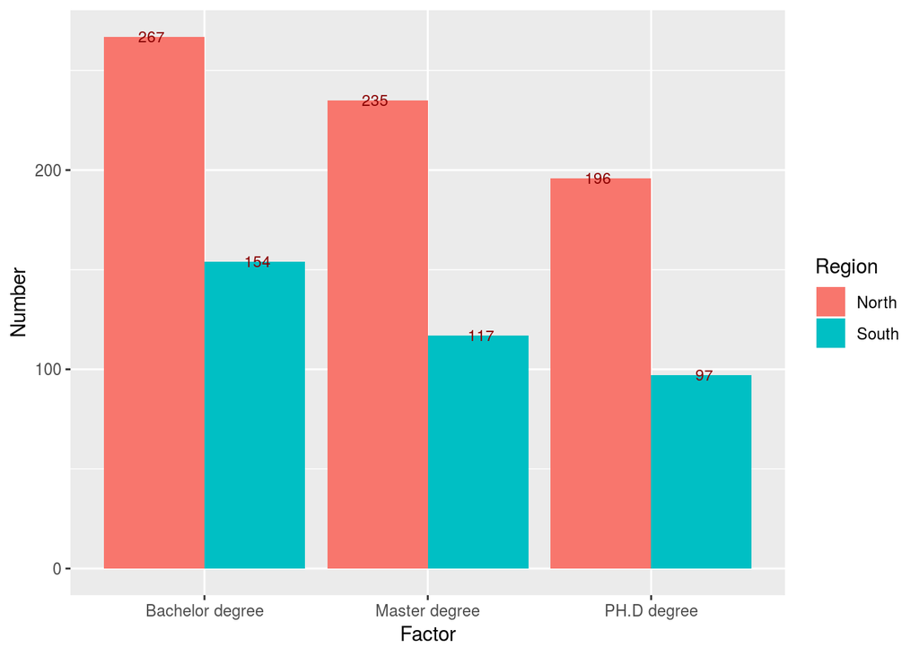

```r
secondtdf = data.frame(
          Region = rep(c("North", "South"), each = 3),
          Factor = rep(c("Bachelor degree", "Master degree","PH.D degree")),
          Number = c(n_bach_N, n_master_N, n_PH.D_N,
                     n_bach_S, n_master_S, n_PH.D_S))

plotsecond = ggplot(data = secondtdf, aes(x = Factor, y = Number, fill = Region)) +
    geom_bar(stat = "identity", position=position_dodge()) +
    geom_text(aes(label = Number), position = position_dodge(0.95), vjust=0.5, color = "darkred", size = 3)

# jpeg('plotsecond.jpg')
# plot(plotsecond)
plotsecond
```

This graph shows the frequency of each factors in the standing variable of jdata set. Each factor is subsetted by region, which is north vs south in California state. The indepedent variables are bachelor degree, master degree and Ph.D.The numbers on top of each bar indicates the frequency of that factor. The color indicates region difference.

Write function to count and put them in decreasing order:

Intputs: 2 columns of language variables that needs to be counted ( North vs South) and Numbers of different language. Output: Dataframe in order of your choice (decreasing/ increasing)

```r
count_order = function(col1, col2, order, top){
  ct1 = count(col1)
  ct2 = count(col2)
  if(order == "decreasing"){
    ct1_inc = ct1[order(ct1$freq, decreasing = T),]
    ct2_inc = ct2[order(ct2$freq, decreasing = T),]

    cl = length(ct1_inc$freq) - length(ct2_inc$freq)

    if(cl < 0){
      fresult = data.frame(Lang1 = c(as.character(ct1_inc$x), rep(NA,abs(cl))),
                            Freq1 = c(ct1_inc$freq, rep(NA,abs(cl))),
                            Lang2 = as.character(ct2_inc$x),
                            Freq2 = ct2_inc$freq)

    } else{
      fresult = data.frame(Lang1 = as.character(ct1_inc$x),
                            Freq1 = ct1_inc$freq,
                            Lang2 = c(as.character(ct2_inc$x), rep(NA,cl)),
                            Freq2 = c(ct2_inc$freq,rep(NA,cl)))
      }
  }
  else{
    ct1_dec = ct1[order(ct1$freq, decreasing = F),]
    ct2_dec = ct2[order(ct2$freq, decreasing = F),]

    cl = length(ct1_dec$freq) - length(ct2_dec$freq)

    if(cl < 0){
      fresult = data.frame(Lang1 = c(as.character(ct1_dec$x), rep(NA,abs(cl))),
                            Freq1 = c(ct1_dec$freq, rep(NA,abs(cl))),
                            Lang2 = as.character(ct2_dec$x),
                            Freq2 = ct2_dec$freq)
    } else{
      fresult = data.frame(Lang1 = as.character(ct1_dec$x),
                            Freq1 = ct1_dec$freq,
                            Lang2 = c(as.character(ct2_dec$x), rep(NA,cl)),
                            Freq2 = c(ct2_dec$freq,rep(NA,cl)))
    }
  }
  for(i in 1:10){
    for(j in 1:10){
      if(fresult$Lang1[i] == fresult$Lang2[j]){
        fresult$Freq1[i] = fresult$Freq1[i] + fresult$Freq2[j]
      }
    }
  }
  if(order == "decreasing"){
    res = fresult[order(fresult$Freq1, decreasing = T),]
  } else {
    res = fresult[order(fresult$Freq1, decreasing = F),]
  }
  return(res[1:top,1:2])
}
```

Plot a histogram to see the prefer language for both prefer language 1 and prefer language 2 Dataframe for counting Language:

```r
sl = count_order(South_sub_st$Preferred_lang1, South_sub_st$Preferred_lang2,"decreasing", 5)
nl = count_order(North_sub_st$Preferred_lang1, North_sub_st$Preferred_lang2,"decreasing", 5)
sl
```

```
##           Lang1 Freq1
## 1           SQL   100
## 2        Python    72
## 3             R    36
## 4          Java    18
## 7 Analysis Tool    12
```

```r
nl
```

```
##    Lang1 Freq1
## 1    SQL   181
## 2 Python   171
## 3      R   102
## 4   Java    35
## 5  C/C++    29
```

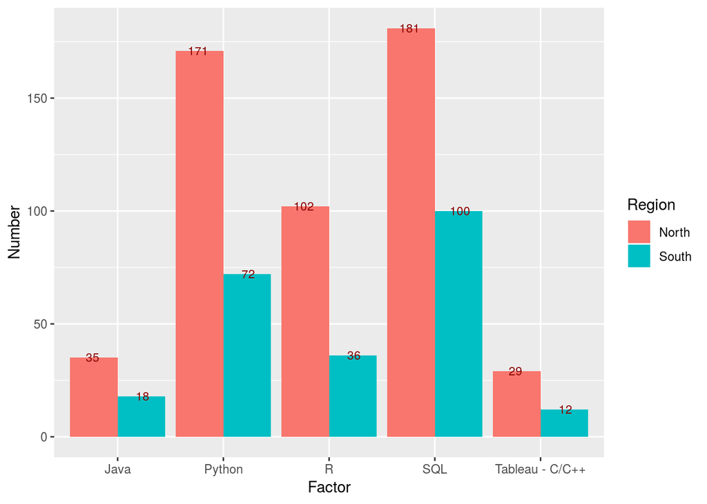

```r
thirddf = data.frame(
          Region = rep(c("North", "South"), each = 5),
          Factor = rep(c("SQL", "Python", "R", "Java", "Tableau - C/C++"),2),
          Number = c(nl$Freq1[1], nl$Freq1[2], nl$Freq1[3], nl$Freq1[4], nl$Freq1[5],
                     sl$Freq1[1], sl$Freq1[2], sl$Freq1[3], sl$Freq1[4], sl$Freq1[5]))

plotthird = ggplot(data = thirddf, aes(x = Factor, y = Number, fill = Region)) +
    geom_bar(stat = "identity", position=position_dodge()) +
    geom_text(aes(label = Number), position = position_dodge(0.95), vjust=0.5, color = "darkred", size = 3)

# jpeg('plotthird.jpg')
# plot(plotthird)
plotthird
```

Calculate the frequency of different Language in different way to double check:

```r
n_cpp_North = length(str_subset(North_sub_st$Preferred_lang1, pattern = "^C\\++$")) +length(str_subset(North_sub_st$Preferred_lang2, pattern = "C\\++$"))

n_cpp_South = length(str_subset(South_sub_st$Preferred_lang1, pattern = "^C\\++$")) +length(str_subset(South_sub_st$Preferred_lang2, pattern = "C\\++$"))

n_java_South = length(str_subset(South_sub_st$Preferred_lang1, pattern = "^Java$")) +length(str_subset(South_sub_st$Preferred_lang2, pattern = "^Java$"))

n_java_North = length(str_subset(North_sub_st$Preferred_lang1, pattern = "^Java$")) +length(str_subset(North_sub_st$Preferred_lang2, pattern = "^Java$"))

n_Python_North = length(str_subset(North_sub_st$Preferred_lang1, pattern = "^Python$"))+length(str_subset(North_sub_st$Preferred_lang2, pattern = "^Python$"))

n_Python_South = length(str_subset(South_sub_st$Preferred_lang1, pattern = "^Python$"))  +length(str_subset(South_sub_st$Preferred_lang2, pattern ="^Python$"))

n_R_North = length(str_subset(North_sub_st$Preferred_lang1, pattern = "^R$")) +length(str_subset(North_sub_st$Preferred_lang2, pattern = "R$"))

n_R_South = length(str_subset(South_sub_st$Preferred_lang1, pattern = "^R$"))  +length(str_subset(South_sub_st$Preferred_lang2, pattern = "R$"))
n_R_South
```

```
## [1] 37
```

```r
n_SQL_North = length(str_subset(North_sub_st$Preferred_lang1, pattern = "^SQL$")) +length(str_subset(North_sub_st$Preferred_lang1, pattern = "/SQL$")) +length(str_subset(North_sub_st$Preferred_lang2, pattern = "^SQL$"))

n_SQL_South = length(str_subset(South_sub_st$Preferred_lang1, pattern = "^SQL$"))+ length(str_subset(South_sub_st$Preferred_lang1, pattern = "/SQL$"))+ length(str_subset(South_sub_st$Preferred_lang2, pattern = "^SQL$"))


res = cbind(nl,sl)
handwaydf = data.frame(NLang1 = c("SQL", "Python", "R", "Java", "C/C++"),
                       NFreg1 = c(n_SQL_North, n_Python_North, n_R_North, n_java_North, n_cpp_North),
                       SLang1 = c("SQL", "Python", "R", "Java", "C/C++"),
                       NLang1 = c(n_SQL_South, n_Python_South, n_R_South, n_java_South, n_cpp_South))
res
```

```
##    Lang1 Freq1         Lang1 Freq1
## 1    SQL   181           SQL   100
## 2 Python   171        Python    72
## 3      R   102             R    36
## 4   Java    35          Java    18
## 5  C/C++    29 Analysis Tool    12
```

```r
handwaydf
```

```
##   NLang1 NFreg1 SLang1 NLang1.1
## 1    SQL    181    SQL      100
## 2 Python    171 Python       72
## 3      R    102      R       37
## 4   Java     35   Java       18
## 5  C/C++     16  C/C++        6
```

Plot a histogram to see the prefer major for both prefer major 1 and prefer major 2 Dataframe for counting Major:

```r
smj = count_order(South_sub_st$Preferred_mj1, South_sub_st$Preferred_mj2,"decreasing", 5)
nmj = count_order(North_sub_st$Preferred_mj1, North_sub_st$Preferred_mj2,"decreasing", 5)
smj
```

```
##                     Lang1 Freq1
## 1        Computer Science    91
## 3              Statistics    42
## 2 Related Technical Field    40
## 5                    Math    21
## 4        Data Engineering    18
```

```r
nmj
```

```
##                     Lang1 Freq1
## 1        Computer Science   189
## 2              Statistics   128
## 3 Related Technical Field    61
## 5                    Math    34
## 4        Machine Learning    30
```

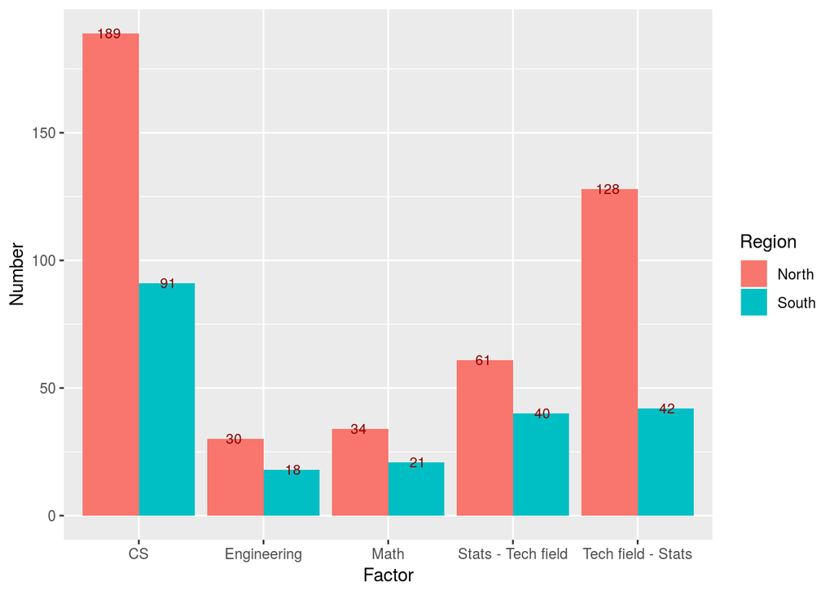

```r
forthdf = data.frame(
          Region = rep(c("North", "South"), each = 5),
          Factor = rep(c("CS", "Tech field - Stats", "Stats - Tech field", "Math", "Engineering"),2),
          Number = c(nmj$Freq1[1], nmj$Freq1[2], nmj$Freq1[3], nmj$Freq1[4], nmj$Freq1[5],
                     smj$Freq1[1], smj$Freq1[2], smj$Freq1[3], smj$Freq1[4], smj$Freq1[5]))

plotforth = ggplot(data = forthdf, aes(x = Factor, y = Number, fill = Region)) +
    geom_bar(stat = "identity", position=position_dodge()) +
    geom_text(aes(label = Number), position = position_dodge(0.95), vjust=0.5, color = "darkred", size = 3)

# jpeg('plotforth.jpg')
# plot(plotforth)
plotforth
```

Combining 1 and 2 together:

```r
combinedf = data.frame(
          Region = rep(c("North", "South"), each = 6),
          Factor = c("XP_N(m)", "SalN(k)", "#CompN", "#Ba_N", "#Ma_N", "#PHD_N", "XP_S(m)", "SalS(k)", "#CompS", "#Ba_S", "#Ma_S", "#PHD_S"),
          Number = c(avg_exp_N, North_Est_min_salary, sum(n_companies_north), n_bach_N, n_master_N, n_PH.D_N, avg_exp_S, South_Est_min_salary, sum(n_companies_south), n_bach_S, n_master_S, n_PH.D_S))


plotcombine = ggplot(data = combinedf, aes(x = Factor, y = Number, fill = Region)) +
    geom_bar(stat = "identity", position=position_dodge()) +
    geom_text(aes(label = Number), position = position_dodge(0.95), vjust=0.5, color = "darkred", size = 3)
jpeg('plotcombine.jpg')
plot(plotcombine)
plotcombine
```

3 - Write function to find out suitable companies: “find_company” that has 4 agrument. Minimum standing, experience, region, best language. It will return the dataframe that has all the company that fit our agruments

Let’s just use the top 20 preferred language:

```r
top20 = count_order(jdata$Preferred_lang1, jdata$Preferred_lang2,"decreasing", 20)
top20
```

```
##                                                  Lang1 Freq1
## 1                                                  SQL   281
## 2                                               Python   243
## 3                                                    R   138
## 4                                                 Java    53
## 5                                                C/C++    40
## 8                                        Analysis Tool    31
## 6                                                Excel    23
## 10                                             Tableau    20
## 7                                            MS Office     8
## 9                                                  SAS     5
## 11                                          JavaScript     4
## 12                                            MS Excel     3
## 13                                               NoSQL     3
## 14                                               MySQL     2
## 15                        Related Programming Language     2
## 16                                                Ruby     2
## 17                                               Scala     2
## 18                                               Spark     2
## 19 3D Modeling Tools ( Illustrator, SketchUp, or Poly)     1
## 20                                                 3NF     1
```

Change the data in the way that if “Bachelor”/“All levels” is able to be looked at means Easy, “Master” means Medium and “PHD” will be Hard.

Our function will now base on Difficulty, Experience, Region, Best Language:

```r
for (i in 1:length(jdata$Standing)){
  if(!is.na(str_extract(jdata$Standing[i], pattern = "^B")) || !is.na(str_extract(jdata$Standing[i], pattern = "^A"))){
    jdata$Difficulty[i] = "Easy"
  } else if (!is.na(str_extract(jdata$Standing[i], pattern = "^M"))){
    jdata$Difficulty[i] = "Medium"
  } else if (!is.na(str_extract(jdata$Standing[i], pattern = "^P"))){
    jdata$Difficulty[i] = "Hard"
  }
}
```

Function find_company using intersect and union subsets. The input of the function will be Difficulty, Minimum years of experience, region and language in Jdata set. The output will be the list of companies name that satisfied the arguments.

```r
find_company = function(Difficulty, Exp, Region,Language){
  Argu_y = jdata$Company[which(jdata$Difficulty == Difficulty)]
  Argu_x = jdata$Company[which(jdata$Min_exp <= Exp)]
  Argu_z = jdata$Company[which(jdata$Region == Region)]
  Argu_u1 = jdata$Company[which(jdata$Preferred_lang1 == Language)]
  Argu_u2 = jdata$Company[which(jdata$Preferred_lang2 == Language)]

  return(union(intersect(intersect(Argu_x,Argu_y),intersect(Argu_z,Argu_u1)),intersect(intersect(Argu_x,Argu_y),intersect(Argu_z,Argu_u2))))

}
find_company("Medium", 5, "South CA","R")
```

```
##  [1] "Kensho"                       "Hulu"
##  [3] "Lieberman Research Worldwide" "Aspiration"
##  [5] "Motive Interactive"           "Fox Network Group"
##  [7] "Zebit"                        "Experian"
##  [9] "Amazon"                       "Sony PlayStation"
## [11] "ZestFinance"                  "Upstart"
```

Another way using subset find_company:

```r
n_find_company = function(Difficulty, Exp, Region,Language){
a = jdata$Company[which(jdata$Difficulty == Difficulty),]
b = jdata$Company[which(jdata$Min_exp <= Exp),]
c = jdata$Company[which(jdata$Region == Region),]
d1 = jdata$Company[which(jdata$Preferred_lang1 == Language),]
d2 = jdata$Company[which(jdata$Preferred_lang2 == Language),]

pre_r1 = a[which(a$Min_exp <= Exp)]
nex_r1 = pre_r1[which(pre_r1$Region == Region)]
r1     = nex_r1[which(nex_r1$Preferred_lang1 == Language)]

pre_r2 = a[which(a$Min_exp <= Exp)]
nex_r2 = pre_r2[which(pre_r2$Region == Region)]
r2     = nex_r2[which(nex_r2$Preferred_lang2 == Language)]

rbind(r1,r2)
}
find_company("Medium", 5, "South CA","R")
```

```
##  [1] "Kensho"                       "Hulu"
##  [3] "Lieberman Research Worldwide" "Aspiration"
##  [5] "Motive Interactive"           "Fox Network Group"
##  [7] "Zebit"                        "Experian"
##  [9] "Amazon"                       "Sony PlayStation"
## [11] "ZestFinance"                  "Upstart"
```

4- Comparing between Data Scientist and Data Engineer and Data Analyst. Base on jdata. - Number of Data Scientist vs number of Data Engineer - Top 3 language for Data Scientist vs Data Engineer - Best est_min_avg salary for each - City that offer the most Data Scientist position vs Data Engineer.

Finding total number of Data Engineers and Data Scientists in North and South of California state using String R:

```r
major = count(jdata$Position)
count(North_sub_st$Position)
```

```
##                                                                                         x
## 1                                                   A9 Fall 2018 Applied Scientist Intern
## 2                                                            Algorithm & Machine Learning
## 3                                                          Algorithm Scientist Internship
## 4                                                        Apple Operation Sr. Data Analyst
## 5                                                           Application Security Engineer
## 6                                            Applied Research Scientist: Machine Learning
## 7                                                        Artificial intelligence Engineer
## 8                                                     Big Data - Big Data Platform Intern
## 9                                                                       Big data engineer
## 10                                                                  Business Data Analyst
## 11                                                                  Business/Data Analyst
## 12                                                               Clinical Data Manager II
## 13                                                Consulting Data Analyst - Excel, Access
## 14                                                               Contingent: Data Analyst
```

[output cut: 291 more lines]

```r
n_eng_north = length(str_subset(North_sub_st$Position, pattern = "^Data Engineer"))+length(str_subset(North_sub_st$Position, pattern = "Data Engineer$")) - length(str_subset(North_sub_st$Position, pattern = "^Data Engineer$"))
n_eng_north
```

```
## [1] 44
```

```r
n_eng_south = length(str_subset(South_sub_st$Position, pattern = "^Data Engineer"))+length(str_subset(South_sub_st$Position, pattern = "Data Engineer$")) - length(str_subset(South_sub_st$Position, pattern = "^Data Engineer$"))
n_eng_south
```

```
## [1] 32
```

```r
n_sci_north =  length(str_subset(North_sub_st$Position, pattern = "^Data Scientist"))+length(str_subset(North_sub_st$Position, pattern = "Data Scientist$")) - length(str_subset(North_sub_st$Position, pattern = "^Data Scientist$"))
n_sci_north
```

```
## [1] 138
```

```r
n_sci_south = length(str_subset(South_sub_st$Position, pattern = "^Data Scientist"))+length(str_subset(South_sub_st$Position, pattern = "Data Scientist$")) - length(str_subset(South_sub_st$Position, pattern = "^Data Scientist$"))
n_sci_south
```

```
## [1] 59
```

Comparing between numbers of data engineers and data scientists in the North and the South of California (using side-by-side histogram):

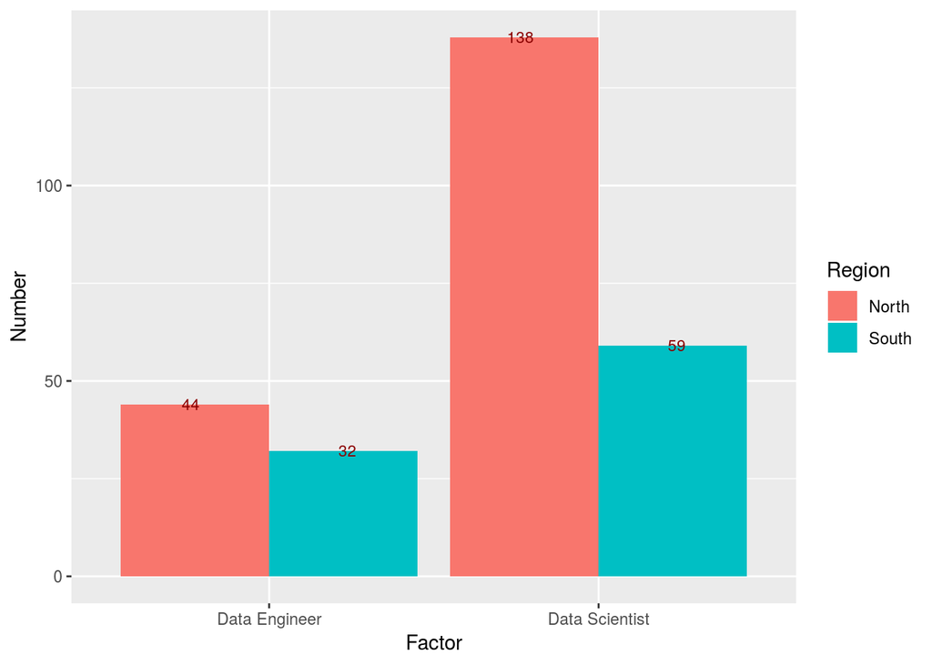

```r
P_data_fr = data.frame(Region = c("North","South","North","South"),
  Number = c(n_eng_north,n_eng_south,n_sci_north,n_sci_south),
  Factor = rep(c("Data Engineer","Data Scientist"),each = 2)
)

Plot_1 = ggplot(data = P_data_fr, aes(x = Factor, y = Number, fill = Region)) +
    geom_bar(stat = "identity", position=position_dodge()) +
    geom_text(aes(label = Number), position = position_dodge(0.95), vjust=0.5, color = "darkred", size = 3)

#jpeg('Plot_1.jpg')
#plot(Plot_1)
Plot_1
```

This histogram shows the comparison between the number of data engineer and data scientist in north and south of California. The independent variables are data engineer and data scientist, and the number on top of them represent their frequency.

Top 3 language for Data Scientist vs Data Engineer

Set up 2 subsets for Data Scientist and Engineer in California State:

```r
Standing_sub = jdata[which(jdata$Standing != "NA"),]
Eng_sub = Standing_sub[which(Standing_sub$Position == "Data Engineer"),]
Sci_sub = Standing_sub[which(Standing_sub$Position == "Data Scientist"),]
Ana_sub = Standing_sub[which(Standing_sub$Position == "Data Analyst"),]
nrow(Eng_sub)
```

```
## [1] 49
```

```r
nrow(Sci_sub)
```

```
## [1] 159
```

```r
nrow(Ana_sub)
```

```
## [1] 70
```

Number of top 3 most used lanuage (Python, R, SQL) in Data Engineer vs Data Scientist position:

```r
n_Python_Eng = length(str_subset(Eng_sub$Preferred_lang1, pattern = "Python"))+length(str_subset(Eng_sub$Preferred_lang2, pattern = "Python"))
n_Python_Eng
```

```
## [1] 26
```

```r
n_Python_Sci = length(str_subset(Sci_sub$Preferred_lang1, pattern = "Python"))+length(str_subset(Sci_sub$Preferred_lang2, pattern = "Python"))
n_Python_Sci
```

```
## [1] 94
```

```r
n_R_Eng = length(str_subset(Eng_sub$Preferred_lang1, pattern = "R"))+length(str_subset(Eng_sub$Preferred_lang2, pattern = "R"))
n_R_Eng
```

```
## [1] 3
```

```r
n_R_Sci = length(str_subset(Sci_sub$Preferred_lang1, pattern = "R"))+length(str_subset(Sci_sub$Preferred_lang2, pattern = "R"))
n_R_Sci
```

```
## [1] 79
```

```r
n_SQL_Eng = length(str_subset(Eng_sub$Preferred_lang1, pattern = "SQL"))+length(str_subset(Eng_sub$Preferred_lang2, pattern = "SQL"))
n_SQL_Eng
```

```
## [1] 31
```

```r
n_SQL_Sci = length(str_subset(Sci_sub$Preferred_lang1, pattern = "SQL"))+length(str_subset(Sci_sub$Preferred_lang2, pattern = "SQL"))
n_SQL_Sci
```

```
## [1] 72
```

Comparing between number of Python, R, SQL in the position of Data Scientist and Data Engineer in California (using side-by-side histogram):

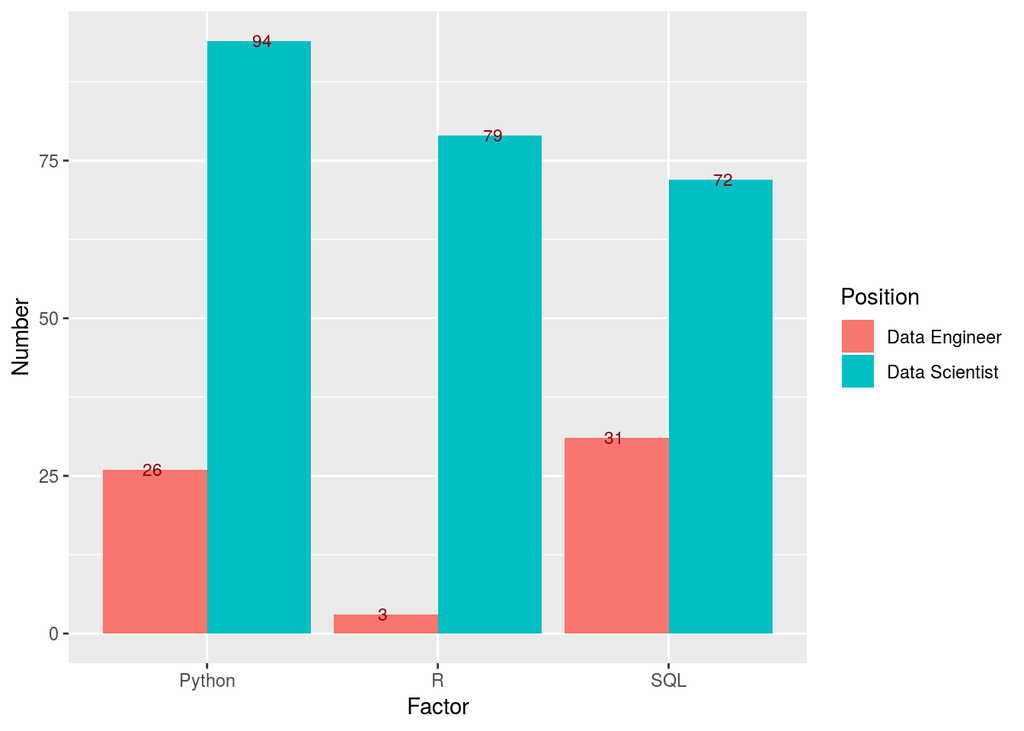

```r
Lang_data_fr = data.frame( Factor =c("Python","R","SQL"),
      Position = rep(c("Data Scientist", "Data Engineer"),each = 3),
      Number =  c(n_Python_Sci,n_R_Sci,n_SQL_Sci,n_Python_Eng,n_R_Eng,n_SQL_Eng))

Plot_position = ggplot(data = Lang_data_fr, aes(x = Factor, y = Number, fill = Position)) +
    geom_bar(stat = "identity", position=position_dodge()) +
    geom_text(aes(label = Number), position = position_dodge(0.95), vjust=0.5, color = "darkred", size = 3)

#jpeg('Plot_position.jpg')
#plot(Plot_position)
Plot_position
```

This histogram shows the number of top 3 most used language in the position of data scientist and data engineer. The histogram is subsetted by postion of data scientist and data engineer, and the number on top of each bars represents the frequency of different indepedent variables.

Best estimated minimum salary for data scientist and data Engineer

Average Salary

```r
#Use NA.omit to omit to take out NA values then use mean function to find average Salary

Omit_yr_salary_N = na.omit(Eng_sub$Est_min_avg_salary)
Omit_yr_salary_S = na.omit(Sci_sub$Est_min_avg_salary)
Eng_Est_min_salary = round(mean(Omit_yr_salary_N)/1000,2)
Sci_Est_min_salary = round(mean(Omit_yr_salary_S)/1000,2)

Eng_Est_min_salary
```

```
## [1] 113.59
```

```r
Sci_Est_min_salary
```

```
## [1] 109.38
```

Comparing between estimated minimum yearly salary (in thousands) for Data scientist and Data Engineer in California (using side-by-side histogram):

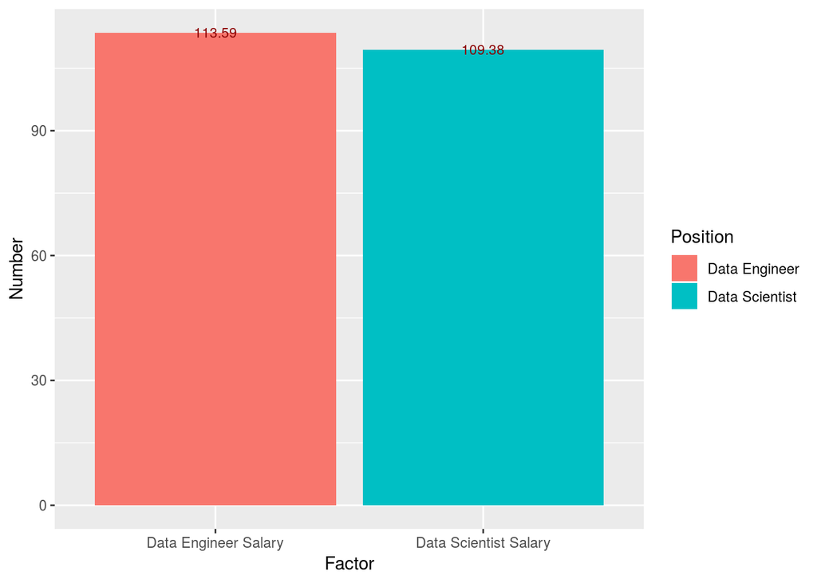

```r
sala_data_frame = data.frame(
  Position = rep(c("Data Scientist", "Data Engineer"),each = 1),
  Number = c(Sci_Est_min_salary,Eng_Est_min_salary),
  Factor = c("Data Scientist Salary","Data Engineer Salary"))

Plot_Salary = ggplot(data = sala_data_frame, aes(x = Factor, y = Number, fill = Position)) +
    geom_bar(stat = "identity", position=position_dodge()) +
    geom_text(aes(label = Number), position = position_dodge(0.95), vjust=0.5, color = "darkred", size = 3)

#jpeg('Plot_Salary.jpg')
#plot(Plot_Salary)
Plot_Salary
```

Finding the top 3 cities that have both most number of data Engineers and data Scientists:

```r
intersect(Sci_sub$City,Eng_sub$City)
```

```
##  [1] "Los Angeles"   "Cupertino"     "Sunnyvale"     "San Francisco"
##  [5] "Santa Monica"  "San Mateo"     "San Diego"     "Palo Alto"
##  [9] "Redwood City"  "Fremont"
```

```r
# count(Eng_sub$City)[order(count(Eng_sub$City)$freq, decreasing = T),]
# count(Sci_sub$City)[order(count(Sci_sub$City)$freq, decreasing = T),]

count_order(Sci_sub$City, Sci_sub$City, "decreasing", 5)
```

```
##           Lang1 Freq1
## 1 San Francisco    98
## 2   Los Angeles    32
## 3 Mountain View    28
## 4     San Diego    28
## 5      San Jose    24
```

```r
count_order(Eng_sub$City, Eng_sub$City, "decreasing", 5)
```

```
##           Lang1 Freq1
## 1 San Francisco    26
## 2     San Mateo    10
## 3   Los Angeles     8
## 4     San Diego     8
## 5    Emeryville     6
```

```r
count_order(Ana_sub$City, Ana_sub$City, "decreasing", 5)
```

```
##           Lang1 Freq1
## 1 San Francisco    32
## 2   Los Angeles    16
## 3     San Diego    16
## 4      El Monte     8
## 5 Mountain View     6
```

```r
#Divide by 2 to get the actual number
```

Number of Data Engineer and Data Scientist in San Francisco, Santa Monica and Los Angeles of California:

```r
n_Eng_San = length(str_subset(Eng_sub$City, pattern = "San Francisco"))
n_Eng_San
```

```
## [1] 13
```

```r
n_Sci_San = length(str_subset(Sci_sub$City, pattern = "San Francisco"))
n_Sci_San
```

```
## [1] 49
```

```r
n_Eng_Mon = length(str_subset(Eng_sub$City, pattern = "Santa Monica"))
n_Eng_Mon
```

```
## [1] 3
```

```r
n_Sci_Mon = length(str_subset(Sci_sub$City, pattern = "Santa Monica"))
n_Sci_Mon
```

```
## [1] 6
```

```r
n_Eng_Los = length(str_subset(Eng_sub$City, pattern = "Los Angeles"))
n_Eng_Los
```

```
## [1] 4
```

```r
n_Sci_Los = length(str_subset(Sci_sub$City, pattern = "Los Angeles"))
n_Sci_Los
```

```
## [1] 16
```

```r
City_Data_fr = data.frame (City = rep(c("Average salary", "Jobs in North", "Joobs in South"),2),
                    Factor = c("Data Scientist","Data Engineer"),
                    Number = c(Eng_Est_min_salary, n_eng_north, n_eng_south, Sci_Est_min_salary,n_sci_north, n_sci_south))

Plot_3 = ggplot(data = City_Data_fr, aes(x = Factor, y = Number, fill = City)) +
    geom_bar(stat = "identity", position=position_dodge())   +
    geom_text(aes(label = Number), position = position_dodge(0.95), vjust= 1.5, color = "darkred", size = 3)

jpeg('Plot_3.jpg')
plot(Plot_3)
Plot_3
```

Combine everything

```r
lang_sci = count_order(Sci_sub$Preferred_lang1, Sci_sub$Preferred_lang2, "decreasing", 5)
lang_eng = count_order(Eng_sub$Preferred_lang1, Eng_sub$Preferred_lang2, "decreasing", 5)


lang_sci
```

```
##    Lang1 Freq1
## 1 Python    94
## 3      R    73
## 2    SQL    67
## 4   Java    18
## 6  C/C++    10
```

```r
lang_eng
```

```
##    Lang1 Freq1
## 2 Python    26
## 1    SQL    25
## 3   Java     9
## 4  NoSQL     4
## 5    AWS     1
```

```r
data = data.frame(Language       = rep(c("Data Engineer", "Data Scientist"),5),
                   Name_Language = c("E_SQL","S_Python","E_Python","S_R","E_Java","S_SQL","E_NoSQL","S_Java","E_AWS", "S_C/C++"),
                   Value         = c(lang_eng$Freq1[1], lang_sci$Freq1[1], lang_eng$Freq1[2], lang_sci$Freq1[2],
                                     lang_eng$Freq1[3], lang_sci$Freq1[3], lang_eng$Freq1[4], lang_sci$Freq1[4], lang_eng$Freq1[5], lang_sci$Freq1[5]))
Language_plot = ggplot(data, aes(fill = Name_Language, y = Value, x = Language)) +
       geom_bar( stat="identity", position = "fill")

jpeg('Language_plot.jpg')
plot(Language_plot)
Language_plot
```

```r
make_conf_mat = function(first, second, third) {
  table(predicted = predicted, actual = actual)
}
```

```r
Ana_sub_sal = Ana_sub[which(Ana_sub$Est_min_avg_salary != "NA"),]
Eng_sub_sal = Eng_sub[which(Eng_sub$Est_min_avg_salary != "NA"),]
Sci_sub_sal = Sci_sub[which(Sci_sub$Est_min_avg_salary != "NA"),]

a_s = mean(Ana_sub_sal$Est_min_avg_salary)
e_s = mean(Eng_sub_sal$Est_min_avg_salary)
s_s = mean(Sci_sub_sal$Est_min_avg_salary)


ct_lang_ana = count_order(Ana_sub$Preferred_lang1, Ana_sub$Preferred_lang2, "decreasing", 5)
ct_lang_eng = count_order(Eng_sub$Preferred_lang1, Eng_sub$Preferred_lang2, "decreasing", 5)
ct_lang_sci = count_order(Sci_sub$Preferred_lang1, Sci_sub$Preferred_lang2, "decreasing", 5)

# ct_lang_ana
# ct_lang_eng
# ct_lang_sci
```

Major mentioned.

```r
count_order(Ana_sub$Preferred_mj1[which(Ana_sub$Preferred_mj1 != "NA")], Ana_sub$Preferred_mj2[which(Ana_sub$Preferred_mj2 != "NA")], "decreasing", 5)
```

```
##                     Lang1 Freq1
## 1        Computer Science    28
## 2              Statistics    22
## 3                Business    10
## 8 Related Technical Field    10
## 5                    Math     8
```

```r
count_order(Eng_sub$Preferred_mj1[which(Eng_sub$Preferred_mj1 != "NA")], Eng_sub$Preferred_mj2[which(Eng_sub$Preferred_mj2 != "NA")], "decreasing", 5)
```

```
##                     Lang1 Freq1
## 1        Computer Science    36
## 2        Data Engineering    10
## 7             Engineering     8
## 3    Software Engineering     5
## 9 Related Technical Field     5
```

```r
count_order(Sci_sub$Preferred_mj1[which(Sci_sub$Preferred_mj1 != "NA")], Sci_sub$Preferred_mj2[which(Sci_sub$Preferred_mj2 != "NA")], "decreasing", 5)
```

```
##              Lang1 Freq1
## 1 Computer Science    81
## 2       Statistics    74
## 4 Data Engineering    25
## 3 Machine Learning    23
## 5             Math    20
```

Standing and experience for the compare:

```r
count(Ana_sub$Standing)
```

```
##            x freq
## 1 All levels   11
## 2      BA/BS   19
## 3         BS   16
## 4      BS/BA   11
## 5   BS/BA/MS    1
## 6      BS/MS    7
## 7         MS    2
## 8     MS/MBA    1
## 9    MS/PH.D    2
```

```r
count(Eng_sub$Standing)
```

```
##            x freq
## 1 All levels   22
## 2      BA/BS    2
## 3         BS   15
## 4      BS/BA    2
## 5      BS/MS    7
## 6    MS/PH.D    1
```

```r
count(Sci_sub$Standing)
```

```
##            x freq
## 1 All levels   45
## 2      BA/BS    2
## 3         BS   12
## 4      BS/BA    6
## 5      BS/MS   12
## 6         MS   18
## 7      MS/MA    1
## 8    MS/PH.D   53
## 9       PH.D   10
```

```r
round(mean(Ana_sub$Min_exp) * 12,1)
```

```
## [1] 27.4
```

```r
round(mean(Eng_sub$Min_exp) * 12,1)
```

```
## [1] 35.3
```

```r
round(mean(Sci_sub$Min_exp) * 12,1)
```

```
## [1] 29.7
```

5 - Linear regression model to find our salary and check if it fit.

Data transformation: Minimum experience

```r
for(i in 1:length(jdata$Min_exp)){
  if(jdata$Min_exp[i] == 1 & !is.na(jdata$Est_min_avg_salary[i])){
    if(jdata$Est_min_avg_salary[i] >= 150000){
      jdata$Min_exp[i] = 4
    }
    else if(jdata$Est_min_avg_salary[i] >= 130000 &
            jdata$Est_min_avg_salary[i] <  150000){
      jdata$Min_exp[i] = 3
    }
    else if (jdata$Est_min_avg_salary[i] >= 100000 &
             jdata$Est_min_avg_salary[i] <  130000){
      jdata$Min_exp[i] = 2
    }
    else{jdata$Min_exp[i] = 1}
  }
}
```

Add variable names: Jobs density to show which city offers lots of position, which city offers less position.

```r
set.seed(2018)
result = jdata$Est_min_avg_salary[which.min(jdata$Est_min_avg_salary)]
for (i in 1:length(jdata$City))
if(count(jdata$City)$freq[which(count(jdata$City)$x == (jdata$City[i]))] > mean(count(jdata$City)$freq)){
  jdata$Jobs_density[i] = "High"
  jdata$City_Bonus[i] = round(rnorm(1, mean = result * 1.5, sd = 1500),1)
} else {
  jdata$Jobs_density[i] = "Low"
  jdata$City_Bonus[i] = round(rnorm(1, mean = result * 1.4, sd = 1500),1)
}
```

Set up bonuses for salary:

```r
set.seed(2018)
for (i in 1:length(jdata$Position)){
  if(str_detect(jdata$Position[i], pattern = "Engineer")){
    jdata$Posi_Bonus[i] = round(rnorm(1, mean = 25000, sd = 1000),1)
  }  else if (str_detect(jdata$Position[i], pattern = "Scientist")){
    jdata$Posi_Bonus[i] = round(rnorm(1, mean = 22000, sd = 1000),1)
  }  else if (str_detect(jdata$Position[i], pattern = "Analyst")){
    jdata$Posi_Bonus[i] = round(rnorm(1, mean = 15000, sd = 1000),1)
  } else {
    jdata$Posi_Bonus[i] = round(rnorm(1, mean = 10000, sd = 1000),1)
  }
}
```

Finding bonuses for with the year of experience:

```r
calc_salary = na.omit(jdata$Est_min_avg_salary)
avg_salary = mean(calc_salary[which(calc_salary >= 100000)])
salaryvsyear = lm(Est_min_avg_salary ~ Min_exp, data = jdata)
summary(salaryvsyear)
```

```
##
## Call:
## lm(formula = Est_min_avg_salary ~ Min_exp, data = jdata)
##
## Residuals:
##    Min     1Q Median     3Q    Max
## -92744 -21779   2224  22394  88626
##
## Coefficients:
##             Estimate Std. Error t value Pr(>|t|)
## (Intercept)  82784.4     3277.8  25.256  < 2e-16 ***
## Min_exp       5996.0      977.3   6.135  2.2e-09 ***
## ---
## Signif. codes:  0 '***' 0.001 '**' 0.01 '*' 0.05 '.' 0.1 ' ' 1
##
## Residual standard error: 30870 on 368 degrees of freedom
##   (179 observations deleted due to missingness)
## Multiple R-squared:  0.09279,    Adjusted R-squared:  0.09033
## F-statistic: 37.64 on 1 and 368 DF,  p-value: 2.199e-09
```

```r
#Since the p-value for this model is very small it looks like the Min_exp is significant.
exp_multiplier = summary(salaryvsyear)$coef[2,1]
```

Set up bonus for Bonuses with years experience

```r
set.seed(2018)
for (i in 1:length(jdata$Min_exp)){
  if(is.na(jdata$Est_min_avg_salary[i])){
    jdata$Exp_Bonus[i] = round(exp_multiplier * jdata$Min_exp[i] / mean(jdata$Min_exp) ,1)
  }  else if(!is.na(jdata$Est_min_avg_salary[i]) & jdata$Est_min_avg_salary[i] >= 100000){
    jdata$Exp_Bonus[i] = round(exp_multiplier * jdata$Min_exp[i] ,1)
  }  else {
    jdata$Exp_Bonus[i] = round(exp_multiplier * jdata$Min_exp[i] /2 ,1)
  }
}
```

Original model:

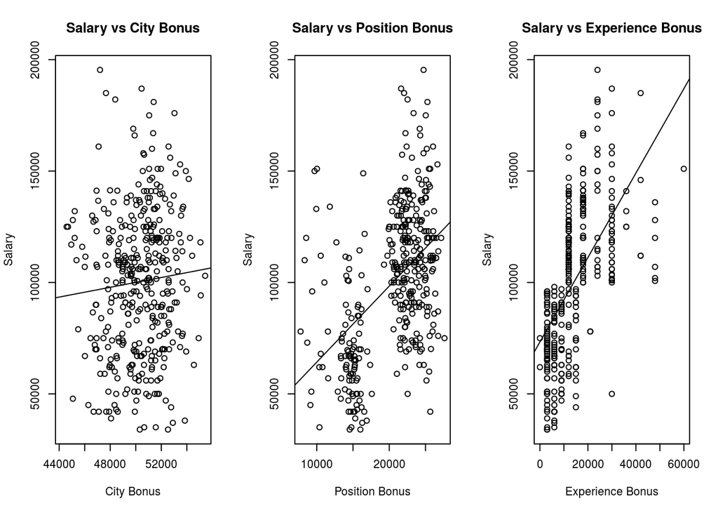

```r
par(mfrow = c(1,3))
model1 = lm(Est_min_avg_salary ~ City_Bonus, data = jdata)
plot(jdata$Est_min_avg_salary ~ jdata$City_Bonus, main = "Salary vs City Bonus", xlab = "City Bonus", ylab = "Salary")
abline(model1)

model2 = lm(Est_min_avg_salary ~ Posi_Bonus, data = jdata)
plot(jdata$Est_min_avg_salary ~ jdata$Posi_Bonus, main = "Salary vs Position Bonus", xlab = "Position Bonus", ylab = "Salary")
abline(model2)

model3 = lm(Est_min_avg_salary ~ Exp_Bonus, data = jdata)
plot(jdata$Est_min_avg_salary ~ jdata$Exp_Bonus, main = "Salary vs Experience Bonus", xlab = "Experience Bonus", ylab = "Salary")
abline(model3)
```

New model:

```r
fit_model = lm(Est_min_avg_salary ~ Exp_Bonus + City_Bonus + Posi_Bonus, data = jdata)
summary(fit_model)
```

```
##
## Call:
## lm(formula = Est_min_avg_salary ~ Exp_Bonus + City_Bonus + Posi_Bonus,
##     data = jdata)
##
## Residuals:
##    Min     1Q Median     3Q    Max
## -68362 -14550  -1380  15914  67126
##
## Coefficients:
##               Estimate Std. Error t value Pr(>|t|)
## (Intercept)  2.048e+04  2.886e+04   0.710    0.478
## Exp_Bonus    1.674e+00  1.220e-01  13.717   <2e-16 ***
## City_Bonus  -2.386e-02  5.803e-01  -0.041    0.967
## Posi_Bonus   2.780e+00  2.699e-01  10.300   <2e-16 ***
## ---
## Signif. codes:  0 '***' 0.001 '**' 0.01 '*' 0.05 '.' 0.1 ' ' 1
##
## Residual standard error: 23120 on 366 degrees of freedom
##   (179 observations deleted due to missingness)
## Multiple R-squared:  0.4939, Adjusted R-squared:  0.4897
## F-statistic: 119.1 on 3 and 366 DF,  p-value: < 2.2e-16
```

```r
full_model = lm(Est_min_avg_salary ~ Min_exp + Exp_Bonus + City_Bonus + Posi_Bonus, data = jdata)
sele_model = step(full_model, direction = "backward", trace = 0)
sele_model
```

```
##
## Call:
## lm(formula = Est_min_avg_salary ~ Min_exp + Exp_Bonus + Posi_Bonus,
##     data = jdata)
##
## Coefficients:
## (Intercept)      Min_exp    Exp_Bonus   Posi_Bonus
##   49182.450   -15504.940        3.991        1.925
```

From the select model, it looks like City Bonus is not really great for the model.

```r
for(i in 1:length(jdata$Est_min_avg_salary)){
  jdata$New_min_avg_salary[i] = jdata$City_Bonus[i] + jdata$Posi_Bonus[i] + jdata$Exp_Bonus[i]
}
```

Compare new salary and estimate one.

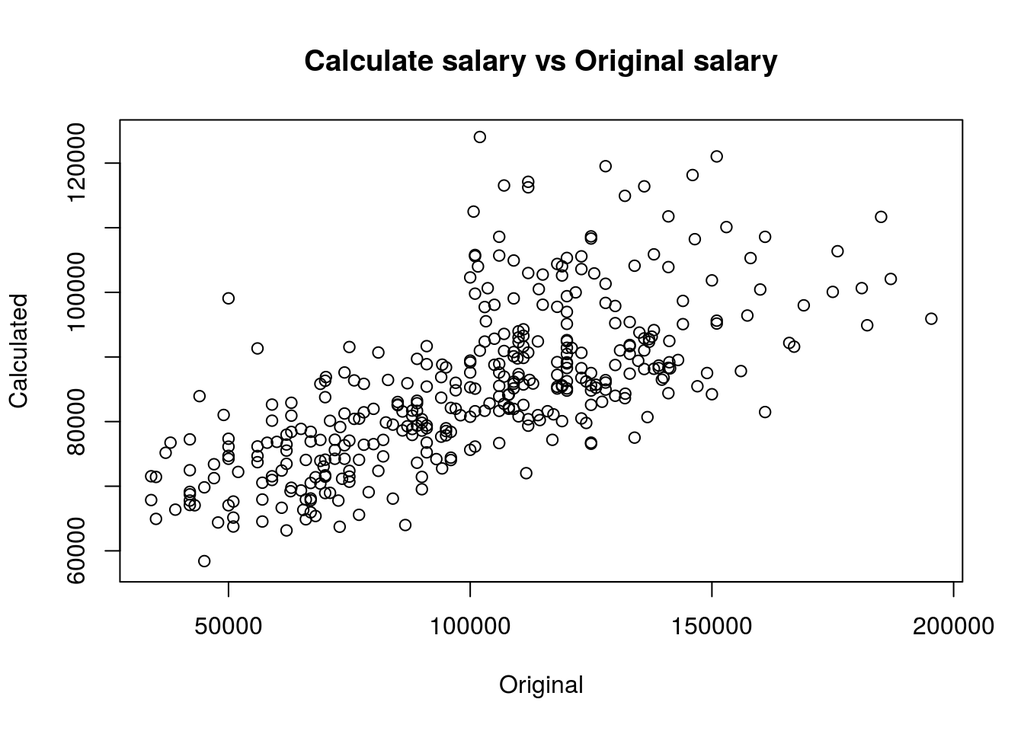

```r
model_compare = lm(Est_min_avg_salary ~ New_min_avg_salary, data = jdata)
plot(jdata$Est_min_avg_salary, jdata$New_min_avg_salary, main = "Calculate salary vs Original salary",
     xlab = "Original", ylab = "Calculated")
```

Logistic Regression model:

Set up logistic model.

```r
for(i in 1:length(jdata$Region)){
  if(jdata$Region[i] == "North CA"){
    jdata$Region_Logic[i] = 1
  } else {
    jdata$Region_Logic[i] = 0
  }
}
```

The model:

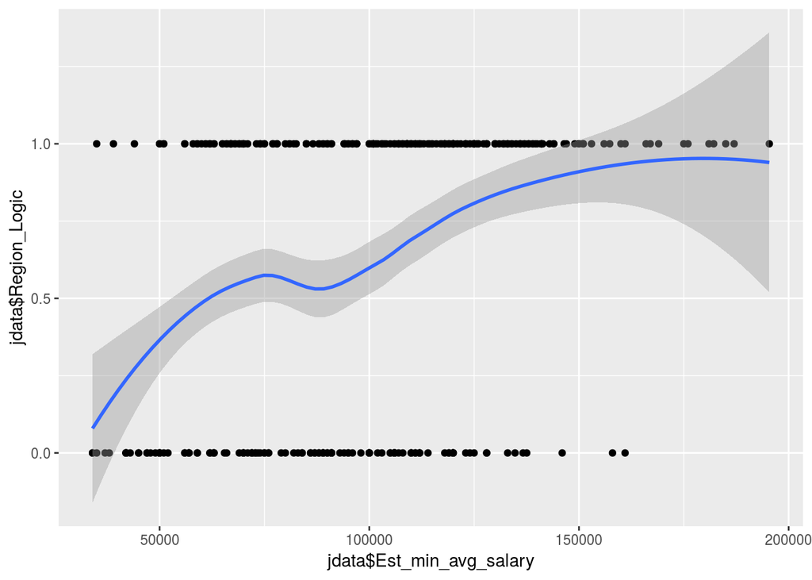

```r
fit_glm = glm(Region_Logic ~ Est_min_avg_salary, data = jdata, family = binomial)
fit_lm  =  lm(Region_Logic ~ Est_min_avg_salary, data = jdata)

qplot(jdata$Est_min_avg_salary, jdata$Region_Logic) + stat_smooth()
```

Find interactions between Region_Logic and the bonuses.

```r
reg_interaction = glm(Region_Logic ~ Est_min_avg_salary + City_Bonus + Posi_Bonus + Exp_Bonus + Est_min_avg_salary:City_Bonus, family = binomial, data = jdata)
summary(reg_interaction)
```

```
##
## Call:
## glm(formula = Region_Logic ~ Est_min_avg_salary + City_Bonus +
##     Posi_Bonus + Exp_Bonus + Est_min_avg_salary:City_Bonus, family = binomial,
##     data = jdata)
##
## Deviance Residuals:
##     Min       1Q   Median       3Q      Max
## -2.5523  -0.9811   0.5032   0.8422   2.0823
##
## Coefficients:
##                                 Estimate Std. Error z value Pr(>|z|)
## (Intercept)                   -2.095e+01  1.053e+01  -1.989   0.0467 *
## Est_min_avg_salary             1.225e-04  1.056e-04   1.160   0.2459
## City_Bonus                     4.189e-04  2.107e-04   1.988   0.0468 *
## Posi_Bonus                    -1.594e-04  3.552e-05  -4.488  7.2e-06 ***
## Exp_Bonus                     -2.542e-05  1.544e-05  -1.646   0.0997 .
## Est_min_avg_salary:City_Bonus -1.571e-09  2.094e-09  -0.750   0.4530
## ---
## Signif. codes:  0 '***' 0.001 '**' 0.01 '*' 0.05 '.' 0.1 ' ' 1
##
## (Dispersion parameter for binomial family taken to be 1)
##
##     Null deviance: 478.49  on 369  degrees of freedom
## Residual deviance: 394.20  on 364  degrees of freedom
##   (179 observations deleted due to missingness)
## AIC: 406.2
##
## Number of Fisher Scoring iterations: 4
```

Conclusion:

By completing this project, we are able to understand more in depth about the basic requirements and information about data - related job in the state of California, in that we are able to create graphs to visualize the behavior of different variables from the data set and write out functions to help obtaining the outputs that would match the conditional inputs.